# Tema 12: Modelos de Ecuaciones Simultáneas

Jorge Sosa-García

Primavera 2023

### 12.1: Motivación de los Modelos de Ecuaciones Simultáneas

En los modelos de ecuaciones simultáneas (SEM) tanto la variable dependiente como, por lo menos, un regresor se determinan de manera conjunta, lo que genera problemas de endogeneidad e inconsistencia en los estimadores de MCO.

Afortunadamente, ya contamos con un método para solucionar el problema de la endogeneidad: las variables instrumentales y el 2SLS. Por tanto, el mayor desafío al que nos enfrentamos con los SEM es el de especificar un modelo con lógica y asegurarnos de que esté identificado.

Veremos cual es la idea detrás de los SEM:

- ¿Cómo se plantean?
- ¿Qué buscamos al especificarlos?
- ¿Cómo nos aseguramos que esté identificado?
- ¿Cómo se estiman?

Para lograr esto, usaremos dos ejemplos relativamente sencillos:

1. Analizaremos un SEM del mercado laboral: veremos la determinación conjunta del salario y el total de horas de trabajo ofertadas por las mujeres casadas.
2. Analizaremos la relación entre inflación y apertura en una economía. Este es un ejemplo siguiendo el trabajo de Romer (1993).

### 12.2. Salarios y oferta laboral

Consideremos la oferta de trabajo de las mujeres que forman parte de la fuerza laboral.

En lugar de plantear un modelo para la demanda, consideraremos un modelo para los salarios ofertados como una función de las variables de productividad que ya conocemos.

Si expresamos ambas ecuaciones en su versión de equilibrio obtenemos:

Ecuación de la oferta laboral de las mujeres (equivalente a una ecuación de oferta):
$$hours = \beta_{10} +
\alpha_1 log(wage) + \beta_{11} educ + \beta_{12} age + \beta_{13}
kidslt6 + \beta_{14} nwifeinc + u_1$$

Ecuación de los salarios ofertados (equivalente a una ecuación de demanda):
$$log(wage) = \beta_{20} +
\alpha_2 hours + \beta_{21} educ + \beta_{22} exper + \beta_{23} exper^2
+ u_2$$

Supondremos que todas las variables del modelo son exógenas, a excepción de `hours` y `log(wage)`. Por ese motivo se usan coeficientes $\alpha$ para las variables endógenas y $\beta$ para las variables exógenas.

Notemos que cada una de estas ecuaciones proporcionan explicaciones de fenómenos distintos y, más aún, cada una de estas ecuaciones tiene una interpretación causal sobre las variables que pretenden explicar. Esta es una característica central del los SEM.

La ecuación de la oferta laboral satisface la condición de orden pues hay dos variables exógenas (`exper` y `exper^2`) que no están presentes en la ecuación de oferta salarial y sólo hay una variable endógena en la ecuación (`log(wage)`).

Esta restricción de exclusión es fundamental: nos indica que, una vez que se controla por `wage`, `educ`, `age`, `kidslt6` y `nwifeinc`, la experiencia laboral no tiene efectos sobre la oferta laboral.

De manera análoga, la ecuación de oferta salarial satisface la condición de orden pues hay tres variables exógenas (`age`, `kidslt6` y `nwifeinc`) que no están presentes en la ecuación de oferta laboral, mientras que sólo hay una variable endógena en la ecuación (`hours`).

En términos de restricciones de exclusión, la ecuación de la demanda nos indica que una vez que se control por `hours`, `educ`, `exper` y `exper^2`, las variables de `age`, `kidslt6` y `nwifeinc` no tienen efecto sobre `log(wage)`.

Dadas las condiciones de orden de ambas ecuaciones, la condición de rango que nos permitirá saber si las ecuaciones están identificadas es verificar que las variables exógenas de cada modelo sean relevantes como instrumento de su respectiva variable endógena.

Esto se puede verificar fácilmente usando las formas reducidas de ambas variables endógenas. Es importante recordar que la forma reducida de una variable endógena es un modelo en el que se usan todas las variables exógenas con las que contamos como variables explicativas.

Forma reducida de `log(wage)`:
$$log(wage) = c_{20} + c_{21} educ + c_{22} age +
c_{23} kidslt6 + c_{24} nwifeinc + c_{25} exper + c_{26} exper^2 + v_2$$

Forma reducida de `hours`:
$$hours = c_{10} + c_{11} educ + c_{12} age + c_{13} kidslt6 + c_{14}
nwifeinc + c_{15} exper + c_{16} exper^2 + v_1$$

Para que la ecuación de oferta salarial esté identificada se debe cumplir que
$$c_{25} \neq 0 \quad \text{o}
\quad c_{26} \neq 0$$
Esto idicaria que los los intrumentos que se están proponiendo para `log(wage)` en la ecuación son relevantes.

Análogamente, para que la ecuación de oferta laboral esté identificada se debe cumplir que
$$c_{12}
\neq 0\quad \text{o} \quad c_{13} \neq 0 \quad \text{o} \quad c_{14}
\neq 0$$
Esto idicaria que los los intrumentos que se están proponiendo para `hours`` en la ecuación son relevantes.

Una vez que se se verificó que el sistema está correctamente planteado y que ambas ecuaciones están identificadas, procedemos a estimar cada una de las ecuaciones usando el método de 2SLS proponiendo como instrumentos para las variables endógenas las variables que se discutieron anteriormente.

```r
# Carga de datos y selección de variables relevantes
data(mroz)
mroz %<>%
  select(wage, hours, educ, age, kidslt6, nwifeinc, exper) %>%
  drop_na(wage)
```

Se verifica la condición de relevancia con las formas reducidas de ambas variables endógenas:

```r
# Forma reducida de log(wage)
mod1 <- lm(log(wage) ~ educ + age + kidslt6 + nwifeinc + exper + I(exper^2),
           data = mroz)
# Forma reducida de hours
mod2 <- lm(hours ~ educ + age + kidslt6 + nwifeinc + exper + I(exper^2),
           data = mroz)
```

Los resultados de las formas reducidas no se presentan pues no son relevantes para nuestro análisis. Lo que nos interesa es la significacnia estadística (conjunta) de los instrumensots propuetos para cada una de las avriables endógneas:

```r
# Prueba para log(wage)
linearHypothesis(mod1, c("exper = 0", "I(exper^2) = 0"))
```

```
## Linear hypothesis test
##
## Hypothesis:
## exper = 0
## I(exper^2) = 0
##
## Model 1: restricted model
## Model 2: log(wage) ~ educ + age + kidslt6 + nwifeinc + exper + I(exper^2)
##
##   Res.Df    RSS Df Sum of Sq      F    Pr(>F)
## 1    423 195.14
## 2    421 186.86  2    8.2815 9.3293 0.0001085 ***
## ---
## Signif. codes:  0 '***' 0.001 '**' 0.01 '*' 0.05 '.' 0.1 ' ' 1
```

```r
# Prueba para hours
linearHypothesis(mod2, c("age = 0", "kidslt6 = 0", "nwifeinc = 0"))
```

```
## Linear hypothesis test
##
## Hypothesis:
## age = 0
## kidslt6 = 0
## nwifeinc = 0
##
## Model 1: restricted model
## Model 2: hours ~ educ + age + kidslt6 + nwifeinc + exper + I(exper^2)
##
##   Res.Df       RSS Df Sum of Sq      F   Pr(>F)
## 1    424 231321286
## 2    421 224200428  3   7120858 4.4571 0.004265 **
## ---
## Signif. codes:  0 '***' 0.001 '**' 0.01 '*' 0.05 '.' 0.1 ' ' 1
```

Una vez verificadas las condiciones de relevancia, procedemos a estimar ambas ecuaciones con 2SLS:

```r
# Estimación de hours (oferta laboral)
mod_suplab <- ivreg(hours ~ log(wage) + educ + age +  kidslt6 + nwifeinc |
                   exper + I(exper^2) + educ + age + kidslt6 + nwifeinc,
                 data = mroz)
# Estimación de log(wage) (oferta salaral)
mod_supsal <- ivreg(log(wage) ~ hours + educ + exper + I(exper^2) |
                   age + kidslt6 + nwifeinc + educ + exper + I(exper^2),
                 data = mroz)
# Presentación de los resultados
stargazer(mod_suplab, mod_supsal, type = "text",
          digits = 3, style = "io",
          dep.var.labels = c("Horas Trabajadas", "Log(Salario)"),
          covariate.labels = c("Log(Salario)", "Horas Trabajadas", "Educación", "Edad",
                               "Hijos Menores", "Ingreso No Femenino", "Experiencia",
                               "Experiencia-SQ", "Constante"))
```

```
##
## -------------------------------------------------------------
##                           Horas Trabajadas     Log(Salario)
##                                 (1)                (2)
## -------------------------------------------------------------
## Log(Salario)                1,639.556***
##                              (470.576)
## Horas Trabajadas                                  0.0001
##                                                  (0.0003)
## Educación                   -183.751***          0.110***
##                               (59.100)           (0.016)
## Edad                           -7.806
##                               (9.378)
## Hijos Menores                 -198.154
##                              (182.929)
## Ingreso No Femenino           -10.170
##                               (6.615)
## Experiencia                                       0.035*
##                                                  (0.019)
## Experiencia-SQ                                    -0.001
##                                                  (0.0005)
## Constante                   2,225.662***         -0.656*
##                              (574.564)           (0.338)
## Observations                    428                428
## R-squared                      -2.008             0.126
## Adjusted R-squared             -2.043             0.117
## Residual standard error 1,354.205 (df = 422) 0.679 (df = 423)
## -------------------------------------------------------------
## Notes:                  ***p < .01; **p < .05; *p < .1
```

Los resultados de la ecuación de oferta laboral indican:

- El signo positivo de `log(wage)` confirma que esta es una ecuación de oferta.
- Si el salario incrementara un 1%, entonces la oferta laboral de las mujeres incrementaría en 16.4 horas.

Los resultados de la ecuación de oferta salarial indican:

- El signo positivo de `hours` confirma que esta es una ecuación de oferta.
- Como el coeficiente de `hours` no es estadísticamente significativo, no hay evidencia de que el salario incremente conforme se aumentan las horas trabajadas.

### 12.3. Inflación y Apertura económica

En 1993, David Romer propuso un modelo en el que buscaba mostrar que una economía más abierta suele tener menores tasas de inflación.

En su análisis, Romer explicaba la tasa de inflación promedio desde 1974 hasta 1993 usando como principal variable explicativa la proporción del PIB que correspondía a las importaciones.

El modelo de Romer es más complejo de lo que nos interesa discutir en este curso, pero se puede consultar su trabajo completo en el siguiente enlace: https://eml.berkeley.edu/~dromer/papers/DRomer_QJE1993.pdf

Aunque Romer no considera su modelo como un SEM, no es difícil pensar que, en realidad, tenía en mente dos ecuaciones:

- Una ecuación que determina la inflación:
  $$inf = \beta_{10} + \alpha_{1} open + \beta_{11}
  log(pcinc) + u_1$$
- Una ecuación que determina la apertura:
  $$open = \beta_{20} + \alpha_{2} inf + \beta_{21}
  log(pcinc) + \beta_{22} log(land) + u_2$$

Para Romer la ecuación de interés es la primera (determinantes de la inflación). En particular, lo que busca mostrar es que $\alpha_1 < 0$.

La segunda ecuación Romer la “usa” para reflejar el hecho de que el grado de apertura de una economía puede depender de la tasa de inflación promedio, o de otras variables.

Para Romer, la variable `log(pcinc`) es exógena, al igual que `log(land)`. De hecho, la idea de usar `log(land)` como una variable exógena es que entre más pequeña sea una economía, más abierta será (note como el tamaño (en área) de una economía no está correlacionada con la inflación).

Derivado de esta discusión, tenemos que la ecuación de los determinantes de la inflación (la de interés para Romer) está identificada pues excluye la variable exógena `log(land)` y tiene una sóla variable endógena, `open`.

Por el contrario, la ecuación de los determinantes de la apertura no está identificada pues no excluye ninguna de las variables exógenas con las que se cuenta y tiene una variable endógena, `inf`.

Recordemos que para que la ecuación de determinantes de la inflación esté identificada no basta con que cumpla el criterio de exlusión. Se debe cumplir también el criterio de relevancia.

Esto es fácil de verificar usando la forma reducida de open:
$$open = c_0 + c_1 log(pcinc) + c_2 log(land) + v2$$
donde lo que se requeire es que
$$c_2 \neq 0$$

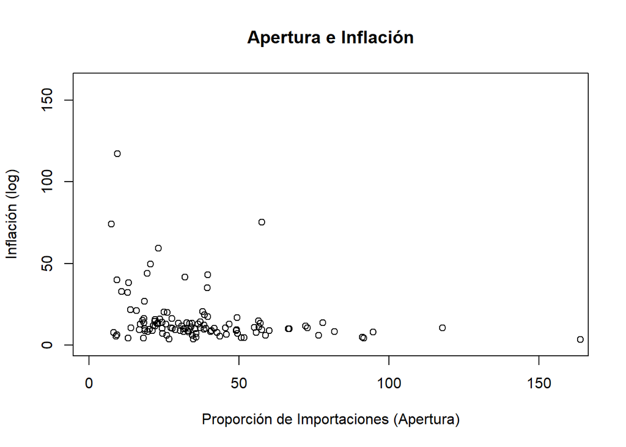

```r
# Carga de datos y selección de variables relevantes
data(openness)
openness %<>%
  select(inf, open, pcinc, land)
# Gráfica preliminar de la relación entre inflación y apertura
with(openness,
     plot(open, inf,
          main = "Apertura e Inflación",
          xlab = "Proporción de Importaciones (Apertura)",
          ylab = "Inflación (log)",
          xlim = c(1, 160), ylim = c(0, 160)
          )
)
```

Verificamos la condición de relevancia de la forma reducida de `open`:

```r
# Estimación de la forma reducida
red_open <- lm(open ~ log(pcinc) + log(land),
               data = openness)
# Presentación de los resultaoos
stargazer(red_open, type = "text",
          digits = 3, style = "io",
          dep.var.labels = c("Apertura"),
          covariate.labels = c("Log(IPC)", "Log(Tamaño)", "Constante"),
          report=("vc*sp"))
```

```
##
## ------------------------------------------------------
##                                    Apertura
## ------------------------------------------------------
## Log(IPC)                            0.546
##                                    (1.493)
##                                   p = 0.716
##
## Log(Tamaño)                       -7.567***
##                                    (0.814)
##                                   p = 0.000
##
## Constante                         117.085***
##                                    (15.848)
##                                   p = 0.000
##
## Observations                         114
## R-squared                           0.449
## Adjusted R-squared                  0.439
## Residual standard error       17.796 (df = 111)
## F statistic                45.165*** (df = 2; 111)
## ------------------------------------------------------
## Notes:                  ***p < .01; **p < .05; *p < .1
```

```r
# Prueba de relevancia sobre el coeficiente de interés
linearHypothesis(red_open, c("log(land) = 0"))
```

```
## Linear hypothesis test
##
## Hypothesis:
## log(land) = 0
##
## Model 1: restricted model
## Model 2: open ~ log(pcinc) + log(land)
##
##   Res.Df   RSS Df Sum of Sq      F    Pr(>F)
## 1    112 62505
## 2    111 35152  1     27353 86.373 1.513e-15 ***
## ---
## Signif. codes:  0 '***' 0.001 '**' 0.01 '*' 0.05 '.' 0.1 ' ' 1
```

Una vez verificada la condición de relevancia, procedemos a estimar la ecuación identificada con 2SLS:

```r
# Estimacón con 2SLS
est_inf <- ivreg(inf ~ open + log(pcinc) |
                   log(land) + log(pcinc),
                 data = openness)
# Presentación de los resultados
stargazer(red_open, est_inf, type = "text",
          digits = 3, style = "io",
          dep.var.labels = c("Apertura", "Inflación"),
          covariate.labels = c("Apertura", "Log(IPC)", "Log(Tamaño)", "Constante"))
```

```
##
## -----------------------------------------------------------------------
##                                           Apertura          Inflación
##                                              OLS           instrumental
##                                                              variable
##                                              (1)               (2)
## -----------------------------------------------------------------------
## Apertura                                                     -0.337**
##                                                              (0.144)
## Log(IPC)                                    0.546             0.376
##                                            (1.493)           (2.015)
## Log(Tamaño)                               -7.567***
##                                            (0.814)
## Constante                                117.085***          26.899*
##                                           (15.848)           (15.401)
## Observations                                 114               114
## R-squared                                   0.449             0.031
## Adjusted R-squared                          0.439             0.013
## Residual standard error (df = 111)         17.796             23.836
## F statistic                        45.165*** (df = 2; 111)
## -----------------------------------------------------------------------
## Notes:                             ***p < .01; **p < .05; *p < .1
```